# Import fish and manipulate data a bit

Minimum vis for fish analysis = 2-m

Visibility data for 2015 are fake. DI was bad and set at 1.0 m; other sites set at 3.0 m

# FISH

## Fish

Fish depth = 5, 10

## Fish and YOY plot

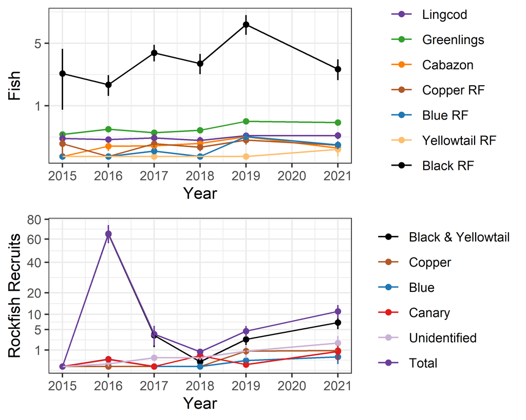

# KELP / ALGAE

## Canopy kelp

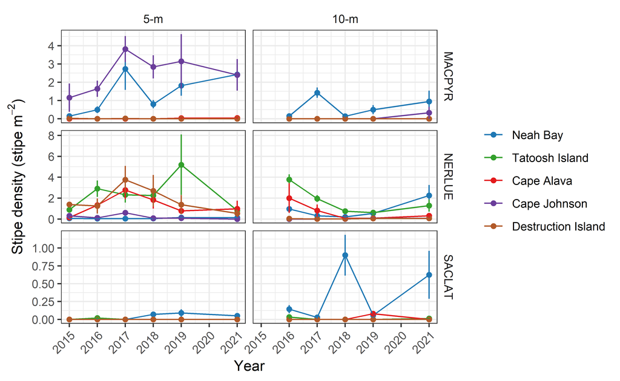

## Caonopy kelp 5 m only

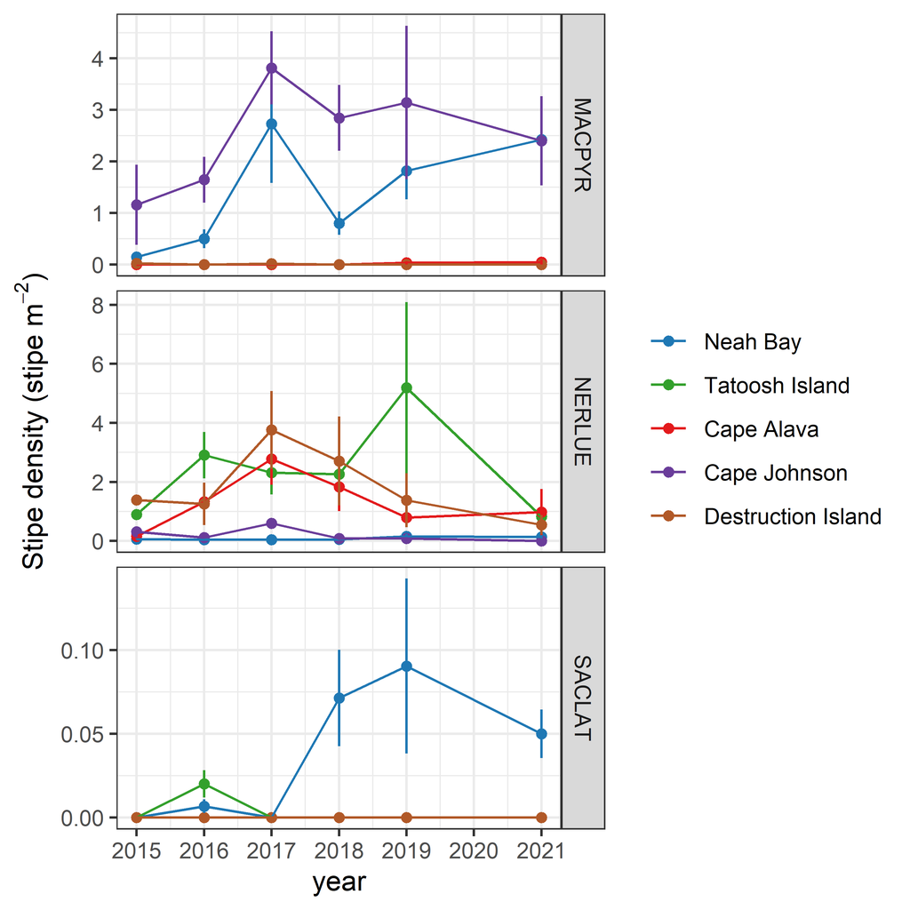

## Nerocystis at Tatoosh

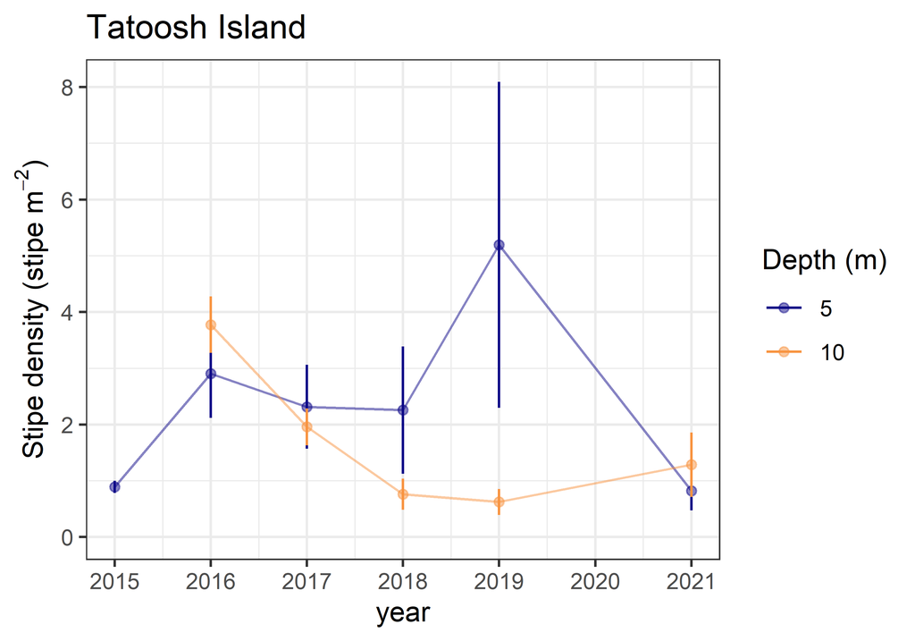

## Nero and Macro

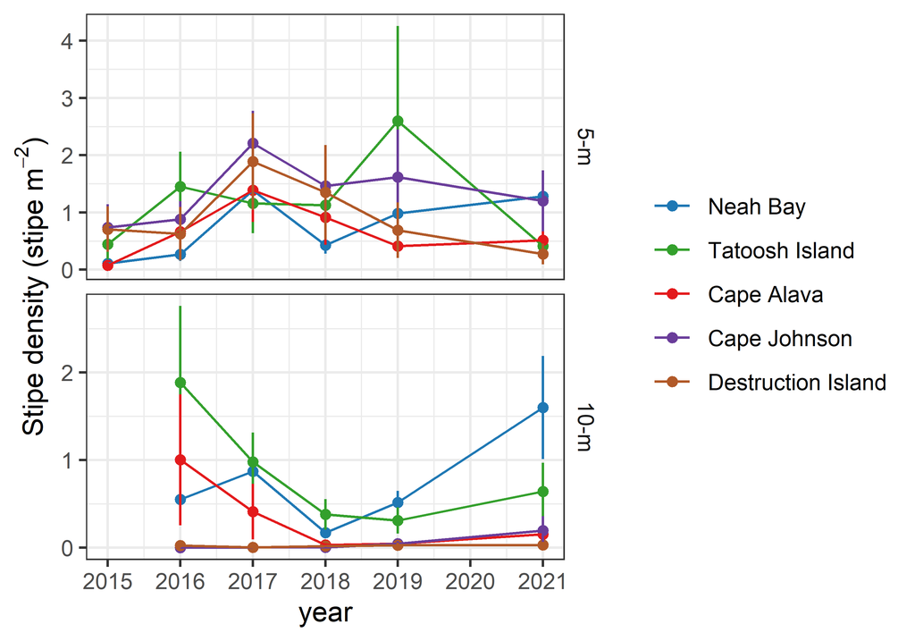

## Big three

Plot the big 3 species: Macro, Nero, Ptero

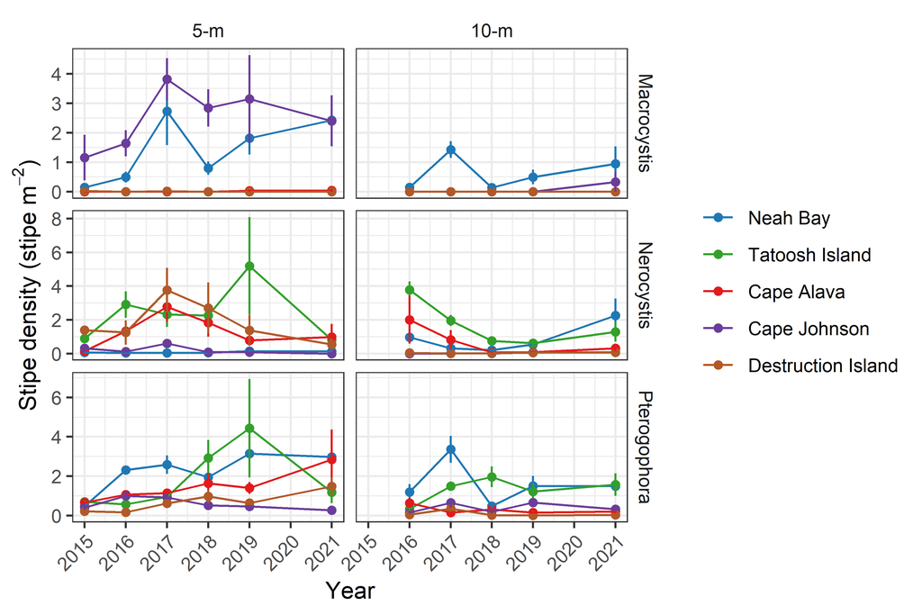

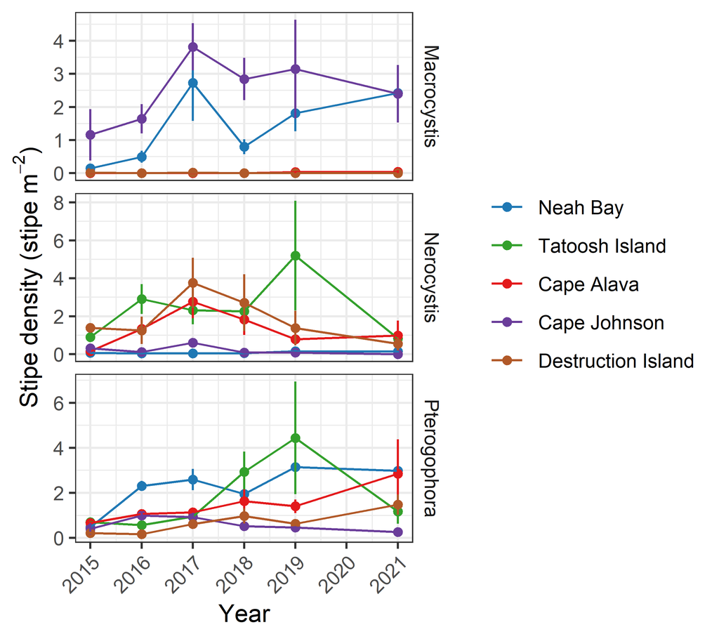

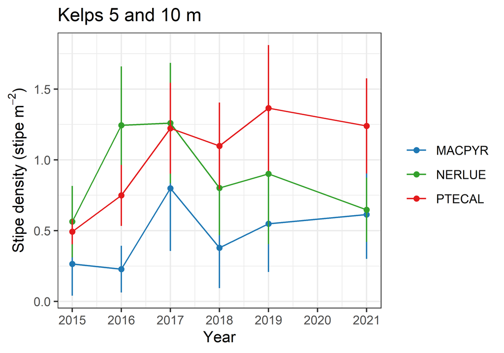

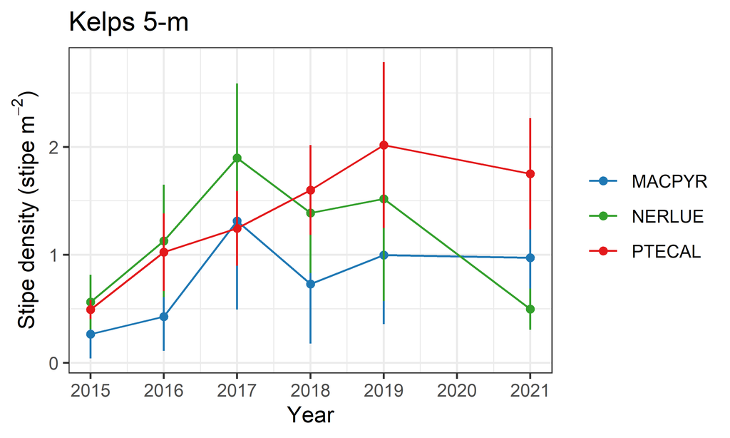

# INVERTEBRATES

## Summed Urchins

Ole will want to clean up the figure

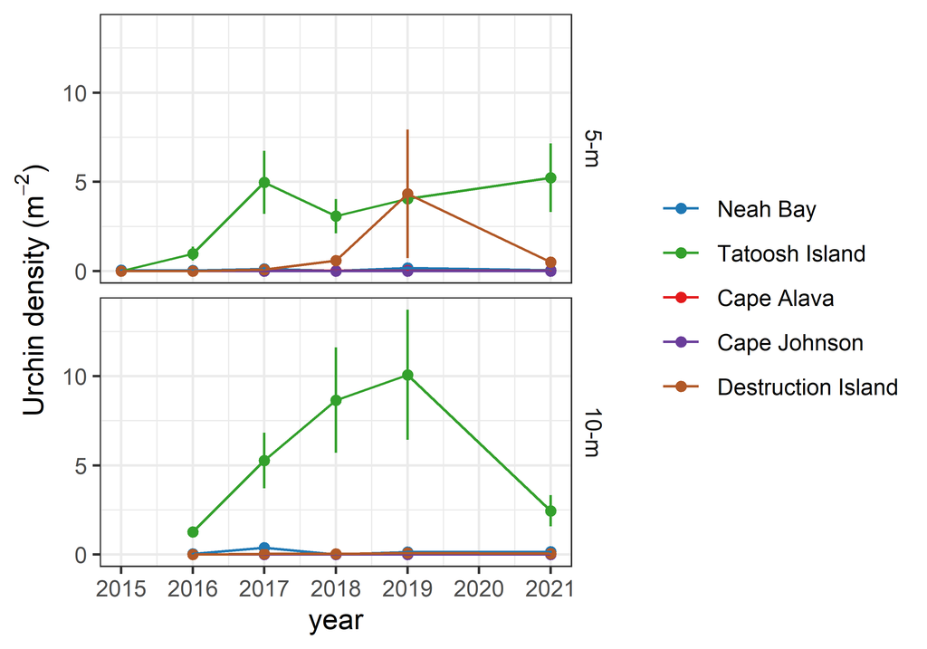

## Urchins by species

Probably worth dropping into the supplement to show that it was mostly purple urchins. Partly interesting because there is no purple urchin fishery, but there is a red one. I think.

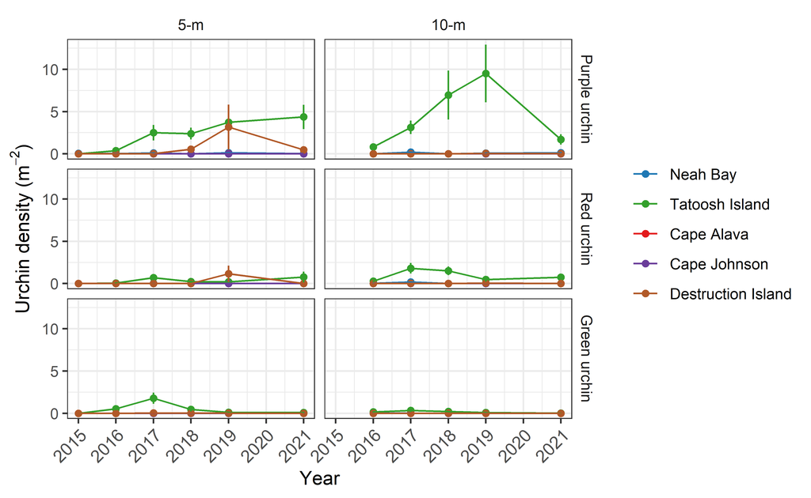